# Road Network Vulnerability with a Case Study: 2024 Noto Earthquake

Student ID: 2554354

# 1 Introduction

Spatial network data has been introduced to many natural disaster analyses. However, previous research generally focused on the distribution of spatial vulnerabilities against natural disasters and few on the risk generated by spatial features. (Pinto1 et al.2024) Identifying the geographical features that could cause secondary damage is meaningful, for example, a traffic jam potentially hinders aid distribution. This study aims to analyze the vulnerability of a road network and spot the critical nodes for recovery of the road efficiency and capacity when road paths are interrupted due to something such as natural disasters.

This study incorporates a recent disaster that happened on 1st January in Japan, the 2024 Noto Peninsula earthquake, where the road network was damaged seriously, and the limitation of transportation affected the recovery of the area. (Suppasri et al.2024) Several earthquakes and typhoons hit this region in a few decades, including “the M6.9 Noto-Hanto earthquake that occurred on March 25, 2007” (Nakajima et al.2024). Additionally, the Noto peninsula has a unique geometry, which is elongated in a north-south direction and closure of the root roads can cause hindrance of recovery within the whole peninsula. Identification of critical nodes and edges in this region allows us to have efficient preparedness for mitigating damage and rapid restorations from the damage. Therefore, spatial analysis for vulnerability is required to recover the region after natural disasters.

In addition to the case study, algorithms are introduced into this study to examine whether they can predict road performance correctly. Projections of natural disasters and damages are important in downtown and the disaster-prone areas. Algorithms commonly used for road network analysis and a random method are examined to predict a spatial vulnerability by comparing the case study in the Noto Peninsula.

# 2 Methodologies

## 2.1 Installed packages

Some packages are necessary to calculate network vulnerability and visualize the result.

```r
load("previous.RData")
options(repos = c(CRAN = "https://cloud.r-project.org/"))

required_package = c("timechange",
                     "tidyverse",
                     "ggplot2",
                     "stringr",
                     "shiny",
                     "knitr",
                     "corrplot",
                     "corrgram",
                     "proxy",
                     "geojsonio",
                     "stplanr",
                     "leaflet",
                     "terra",
                     "SpatialPosition",
                     "stargazer",
                     "rootSolve",
                     "DescTools",
                     "patchwork",
                     "parallelly",
                     "caret",
                     "rprojroot",
                     "kableExtra",
                     "sf",
                     "igraph",
                     "sfnetworks",
                     "osmdata",
                     "dbscan",
                     "s2",
                     "tidygraph",
                     "purrr",
                     "TSP",
                     "sand",
                     "igraphdata",
                     "patchwork",
                     "accessibility",
                     "osrm",
                     "jquerylib",
                     "ggmap",
                     "rosm",
                     "httr",
                     "png",
                     "grid",
                     "cowplot",
                     "units",
                     "RColorBrewer",
                     "cachem",
                     "dodgr",
                     "geodist",
                     "viridis")

invisible(lapply(required_package, function(pkg){
  if(!requireNamespace(pkg, quietly = TRUE)){
    install.packages(pkg)
  }
  library(pkg, character.only = TRUE)
}))
```

## 2.2 Study Area and Dataset

Datasets of the road network were selected including the Noto Peninsula to analyze the road vulnerability. This region was severely affected by the earthquake that occurred on 1st January 2024.

### 2.2.1 Disaster data (Jan 2024 ~ June 2024)

[The daily road status during the recovery phase of the earthquake](https://www.mlit.go.jp/road/r6noto/index2.html) was provided by the Ministry of Land, Infrastructure, Transport and Tourism (MLIT Japan). The dataset offers restored roads and damaged points from 12th January to 21st March and 25th September. It can be divided into three recovery phases (Early-stage (12th – 18th Jan), Mid-stage (19th Jan – 21st Mar), and Last-stage (25th Sep)) because the change in variable values (nodes and edge numbers, etc.) was observed on only 19th January between 12th January and 21st March.

```r
# create a function to check whether the url is existing
url_exists <- function(url) {
    status <- tryCatch({          # avoid from stopping the run by errors
        res <- HEAD(url)          # HTTP request (not download)
        res$status_code == 200    # HTTP status code = 200 means success
    }, error = function(e) FALSE) # FALSE will return if an error happens
    return(status)                # return TRUE or FALSE
}

# create consecutive integers 240112 to 240621 representing dates
numbers <- sprintf("%06d", seq(240112, 240621))

# get url
valid_urls <- c()
for (num in numbers) {
  url <- paste0("https://www.mlit.go.jp/road/r6noto/", num, "data.zip")
  if (url_exists(url)) {
    valid_urls <- c(valid_urls, url)
  }
}

# download data from the url and unzip files
geojson_data_list <- list()
for (url in valid_urls) {
  # create dates data
  date_num <- paste0("20", sub(".*\\/([0-9]{6})data.*", "\\1", url))
  date <- as.Date(as.character(date_num), format = "%Y%m%d")

  # download file from url
  temp <- tempfile()                             # create a temporary file
  download.file(url, temp, mode = "wb")          # download a url in the temporary file
  unzipped_files <- unzip(temp, list = TRUE)     # unzip a file
  geojson_files <- unzipped_files$Name[grep("\\.geojson$", unzipped_files$Name)] # put only geojson files in `geojson_data_list`

  # read the geojson files and add Date column
  geojson_data <- lapply(seq_along(geojson_files), function(i) {
    file <- geojson_files[i]
    # Read files (avoiding error)
    tryCatch({
    data <- st_read(file) %>%
      mutate(Date = date)                        # add Date column
    return(data)
  }, error = function(e) {
    return(FALSE)
  })
})

  # adjust element names of the list
  list_name <- sub("^json/", "", geojson_files) # remove "json" from the file name
  names(geojson_data) <- list_name              # change the list name of [1] to [5] into json file names

  # add one day "geojson_data" to "geojson_data_list"
  if (length(geojson_data) > 0) {
      geojson_data_list[[url]] <- geojson_data
  }
  # delete the temporary file
  unlink(temp)
}
```

```r
# check the geojson_data_list
head(summary(geojson_data_list))
```

```
##                                                   Length Class  Mode
## https://www.mlit.go.jp/road/r6noto/240112data.zip 4      -none- list
## https://www.mlit.go.jp/road/r6noto/240113data.zip 4      -none- list
## https://www.mlit.go.jp/road/r6noto/240114data.zip 4      -none- list
## https://www.mlit.go.jp/road/r6noto/240115data.zip 4      -none- list
## https://www.mlit.go.jp/road/r6noto/240116data.zip 4      -none- list
## https://www.mlit.go.jp/road/r6noto/240117data.zip 4      -none- list
```

```r
# separate the data into each json file
combined_data <- lapply(list_name, function(name) {
  sf_objects <- lapply(geojson_data_list, function(lst) lst[[name]]) # extract one json file
  combined_sf <- dplyr::bind_rows(sf_objects, .id = "source")        # fill NA in missing columns automatically

  return(combined_sf)
})

names(combined_data) <- list_name
list_name
```

```
## [1] "emergency_restored_section.geojson" "ETC2.0_speed_data.geojson"
## [3] "intercity_travel_time.geojson"      "michinoeki.geojson"
## [5] "recovery_point.geojson"
```

Among these five json files, only restored road data and restored point data are utilized for the analysis. Thus, we create the two data sets as sf objects

#### 2.2.1.1 Restored road data

```r
# extract "emergency_restored_section.geojson"
restored_road_sf <- combined_data[[1]] %>%
  dplyr::rename(road_name = "name",                                  # rename Japanese to English
                notes = "備考", manager = "管理者",
                type = "種別", subtype = "細別",
                memo = "メモ.", memo1 = "メモ..1", memo2 = "メモ..2",
                length = "総延長", reference = "データ出典") %>%
  mutate(length = as.numeric(gsub("m", "", length))) %>%             # convert characters to intenger (road length)
  select(road_name, length, Date, geometry)                          # select only necessary data

head(restored_road_sf)
```

```
## Simple feature collection with 6 features and 3 fields
## Geometry type: LINESTRING
## Dimension:     XY
## Bounding box:  xmin: 136.8686 ymin: 37.14216 xmax: 136.9159 ymax: 37.39444
## Geodetic CRS:  WGS 84
##         road_name  length       Date                       geometry
## 1 国道249号う回路      NA 2024-01-12 LINESTRING (136.8707 37.142...
## 2 国道249号う回路      NA 2024-01-12 LINESTRING (136.8711 37.143...
## 3 国道249号う回路      NA 2024-01-12 LINESTRING (136.8703 37.142...
## 4 国道249号う回路      NA 2024-01-12 LINESTRING (136.8722 37.144...
## 5       国道249号  649.11 2024-01-12 LINESTRING (136.8928 37.388...
## 6       国道249号 1013.19 2024-01-12 LINESTRING (136.9046 37.393...
```

#### 2.2.1.2 Recovery point data

```r
# extract "recovery_point.geojson"
recovery_point_sf <- combined_data[[5]] %>%
  dplyr::rename(point_name = "name",                                   # rename Japanese to English
         road_name = "路線名",
         estimated_place_name = "地名.推定.",
         damage_scale = "_iconSize") %>%
  mutate(damage_scale = sapply(damage_scale, function(x) paste(x, collapse = " "))) %>%
  mutate(damage_scale = recode(damage_scale,                           # icon size represents the scale of damage
                               `30 30` = "restored",
                               `40 40` = "severe damage")) %>%
  select(damage_scale, Date, geometry)                                 # Select only necessary data

head(recovery_point_sf)
```

```
## Simple feature collection with 6 features and 2 fields
## Geometry type: POINT
## Dimension:     XY
## Bounding box:  xmin: 136.7964 ymin: 37.32677 xmax: 137.1235 ymax: 37.43388
## Geodetic CRS:  WGS 84
##   damage_scale       Date                  geometry
## 1     restored 2024-01-12  POINT (137.008 37.42982)
## 2     restored 2024-01-12 POINT (136.8298 37.34082)
## 3     restored 2024-01-12 POINT (136.8195 37.32677)
## 4     restored 2024-01-12  POINT (136.7964 37.3476)
## 5     restored 2024-01-12 POINT (137.1074 37.43147)
## 6     restored 2024-01-12 POINT (137.1235 37.43388)
```

#### 2.2.1.3 Latest status (25/09/2024)

The latest status we can currently obtain is the data on 25th September. It contains various information, so it is installed by a method different from the previous one.

```r
# download all json files
path_disaster <- "data/road/r6noto/map/json/"
geojson_files <- list.files(path_disaster, pattern = "\\.geojson$", full.names = TRUE)
geojson_data <- lapply(geojson_files, function(file) {
  st_read(file)
    })

# necessary data
emergency_restored_section_01 <- geojson_data[[4]]  # last modified date: 25/09/2024
damaged_area_09 <- geojson_data[[2]]                # last modified date: 04/09/2024

## not necessary data
# ETC2.0_speed_data_13 <- geojson_data[[5]]        # last modified date: 25/09/2024
# intercity_travel_time_12 <- geojson_data[[6]]    # last modified date: 25/09/2024
# population_mesh_data_14 <- geojson_data[[10]]    # last modified date: 04/09/2024
# recovery_point_02 <- geojson_data[[11]]          # last modified date: 04/09/2024
# keikai_03 <- geojson_data[[7]]                   # last modified date: 06/08/2024
# recovery_situation_aerial_photography_04 <- geojson_data[[12]]  # last modified date: 06/09/2024
# riyou_05 <- geojson_data[[13]]                   # last modified date: 04/09/2024
# michinoeki_06 <- geojson_data[[8]]               # last modified date: 04/09/2024
# douga_07 <- geojson_data[[3]]                    # last modified date: 04/09/2024
# municipal_road_investigation_08 <- geojson_data[[9]]  # last modified date: 04/09/2024
# spherical_image_10 <- geojson_data[[14]]         # last modified date: 04/09/2024
# damage_situation_aerial_photography_11 <- geojson_data[[1]]  # last modified date: 04/09/2024
```

```r
# extract and modify restored road data
latest_restored_road_sf <- emergency_restored_section_01 %>%
  dplyr::rename(length = "総延長", road_closed = "通行の制限等") %>% # rename Japanese colname into English
  mutate(length = as.numeric(gsub("m", "", length))) %>%             # remove the unit [m] from the length column
  mutate(Date = as.Date("2024-09-25", format = "%Y-%m-%d")) %>%      # add Date column
  select(name, length, Date, geometry)

head(latest_restored_road_sf)
```

```
## Simple feature collection with 6 features and 3 fields
## Geometry type: LINESTRING
## Dimension:     XY
## Bounding box:  xmin: 136.8359 ymin: 37.3709 xmax: 136.9584 ymax: 37.38531
## Geodetic CRS:  WGS 84
##                   name length       Date                       geometry
## 1 輪島市道（嶽登山線）     NA 2024-09-25 LINESTRING (136.9533 37.384...
## 2       林道（小池線）     NA 2024-09-25 LINESTRING (136.838 37.3709...
## 3       林道（小池線）     NA 2024-09-25 LINESTRING (136.8386 37.374...
## 4             輪島市道     NA 2024-09-25 LINESTRING (136.8372 37.380...
## 5             輪島市道     NA 2024-09-25 LINESTRING (136.8408 37.380...
## 6             輪島市道     NA 2024-09-25 LINESTRING (136.8359 37.382...
```

```r
# extract and modify restored point data
latest_recovery_point_sf <- damaged_area_09 %>%
  dplyr::rename(point_name = "name",
         road_name = "路線名",
         damage_scale = "_iconSize") %>%
  mutate(damage_scale = sapply(damage_scale, function(x) paste(x, collapse = " "))) %>%
  mutate(damage_scale = recode(damage_scale,
                               `10 10` = "restored",
                               `20 20` = "severe damage")) %>%
  mutate(Date = as.Date("2024-09-25", format = "%Y-%m-%d")) %>%
  select(damage_scale, Date, geometry)

head(latest_recovery_point_sf)
```

```
## Simple feature collection with 6 features and 2 fields
## Geometry type: POINT
## Dimension:     XY
## Bounding box:  xmin: 136.8139 ymin: 37.07156 xmax: 136.8914 ymax: 37.33256
## Geodetic CRS:  WGS 84
##    damage_scale       Date                  geometry
## 1 severe damage 2024-09-25 POINT (136.8219 37.33256)
## 2 severe damage 2024-09-25 POINT (136.8914 37.22607)
## 3      restored 2024-09-25 POINT (136.8139 37.08038)
## 4      restored 2024-09-25 POINT (136.8165 37.09981)
## 5      restored 2024-09-25 POINT (136.8262 37.13281)
## 6      restored 2024-09-25  POINT (136.827 37.07156)
```

#### 2.2.1.4 Combine the recovery and latest data

```r
# Jan-Jun data + Sep 25th data
all_restored_road_sf <- dplyr::bind_rows(restored_road_sf, latest_restored_road_sf) %>%
  select(length, Date, geometry)

# use later to align the map range of osm data
recovery_bbox = st_bbox(all_restored_road_sf)

# result
head(all_restored_road_sf)
```

```
## Simple feature collection with 6 features and 2 fields
## Geometry type: LINESTRING
## Dimension:     XY
## Bounding box:  xmin: 136.8686 ymin: 37.14216 xmax: 136.9159 ymax: 37.39444
## Geodetic CRS:  WGS 84
##    length       Date                       geometry
## 1      NA 2024-01-12 LINESTRING (136.8707 37.142...
## 2      NA 2024-01-12 LINESTRING (136.8711 37.143...
## 3      NA 2024-01-12 LINESTRING (136.8703 37.142...
## 4      NA 2024-01-12 LINESTRING (136.8722 37.144...
## 5  649.11 2024-01-12 LINESTRING (136.8928 37.388...
## 6 1013.19 2024-01-12 LINESTRING (136.9046 37.393...
```

```r
# combine recovery points
all_recovery_point_sf <- dplyr::bind_rows(recovery_point_sf, latest_recovery_point_sf) %>%
  st_set_crs(4326)

head(all_recovery_point_sf)
```

```
## Simple feature collection with 6 features and 2 fields
## Geometry type: POINT
## Dimension:     XY
## Bounding box:  xmin: 136.7964 ymin: 37.32677 xmax: 137.1235 ymax: 37.43388
## Geodetic CRS:  WGS 84
##   damage_scale       Date                  geometry
## 1     restored 2024-01-12  POINT (137.008 37.42982)
## 2     restored 2024-01-12 POINT (136.8298 37.34082)
## 3     restored 2024-01-12 POINT (136.8195 37.32677)
## 4     restored 2024-01-12  POINT (136.7964 37.3476)
## 5     restored 2024-01-12 POINT (137.1074 37.43147)
## 6     restored 2024-01-12 POINT (137.1235 37.43388)
```

### 2.2.2 Normal times road data (OSM)

OpenStreetMap ([Geofabrik GmbH](https://download.geofabrik.de/asia/japan.html)) provides the road network in normal times and other information including OSM ID and [road types](https://wiki.openstreetmap.org/wiki/Key:highway#Roads) generally used for the calculation of road weight.

```r
# download
road_osm <- read_sf("data/chubu-latest-free/gis_osm_roads_free_1.shp")
# extract only Ishikawa by using recovery road bbox because the data includes other areas
osm_cropped <- st_crop(road_osm, recovery_bbox)

# extract the car road data
car_accessible_classes <- c("motorway", "trunk", "primary", "secondary")
osm_car <- osm_cropped %>%
  filter(fclass %in% car_accessible_classes)

# extract all LINESTRING for the later calculation
geom_types <- st_geometry_type(osm_car)
osm_car_roads <- osm_car[geom_types != "POINT", ]     # remove point data
osm_car_roads <- st_cast(osm_car_roads, "LINESTRING") # convert into LINESTRING

# check the data
head(osm_car_roads)
```

```
## Simple feature collection with 6 features and 10 fields
## Geometry type: LINESTRING
## Dimension:     XY
## Bounding box:  xmin: 136.9073 ymin: 36.63846 xmax: 136.9997 ymax: 37.09822
## Geodetic CRS:  WGS 84
## # A tibble: 6 × 11
##   osm_id    code fclass   name        ref   oneway maxspeed layer bridge tunnel
##   <chr>    <int> <chr>    <chr>       <chr> <chr>     <int> <dbl> <chr>  <chr>
## 1 23323177  5111 motorway 能越自動車… E41   F             0     0 F      F
## 2 23323214  5112 trunk    国道160号   160   B             0     0 F      F
## 3 25807756  5113 primary  石川県道47… 47    B            50     0 F      F
## 4 25808566  5113 primary  石川県道47… 47    B            40     0 F      F
## 5 25808599  5113 primary  能登島大橋  47    B             0     0 T      F
## 6 25808823  5113 primary  七尾輪島線  1     B            40     0 F      F
## # ℹ 1 more variable: geometry <LINESTRING [°]>
```

### 2.2.3 Local Authority Data

To map the above road network clearly, local authority data in Ishikawa is downloaded from [here](https://nlftp.mlit.go.jp/ksj/gml/datalist/KsjTmplt-N03-2024.html).

```r
# download the local authority data
la <- st_read("data/N03-20240101_17_GML/N03-20240101_17.geojson")
```

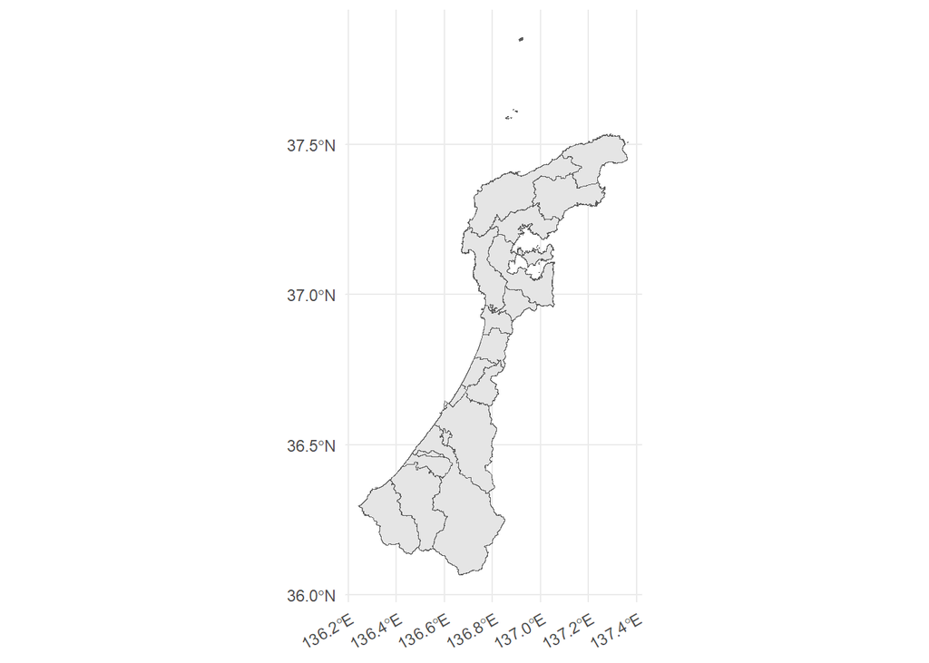

```r
# check the map to decide the geographical range
ggplot() +
  geom_sf(data = la) +
  theme_minimal() +
  theme(axis.text.x = element_text(angle = 30, hjust = 1))
```

### 2.2.4 Cropping the data

We can find the Noto peninsula located in the northern part of Ishikawa in the above map, so the range is clipped above 37.0$^\circ$N. (37.0°N to 37.7°N, 136.6°E to 137.4°E)

```r
# Define coordinates
bbox_values <- c(xmin = 136.6, ymin = 37, xmax = 137.4, ymax = 37.7)

# Create the bounding box
bbox_sf <- st_bbox(bbox_values)
bbox_sf
```

```
##  xmin  ymin  xmax  ymax
## 136.6  37.0 137.4  37.7
```

```r
# crop the all sf objects
all_restored_road_sf <- st_crop(all_restored_road_sf, bbox_sf)
all_recovery_point_sf <- st_crop(all_recovery_point_sf, bbox_sf)

osm_car_roads <- st_crop(osm_car_roads, bbox_sf)

la_cropped <- st_crop(la, bbox_sf)
```

#### 2.2.4.1 Check data by mapping

Here, we visualize the road map separated by the type to understand basic information.

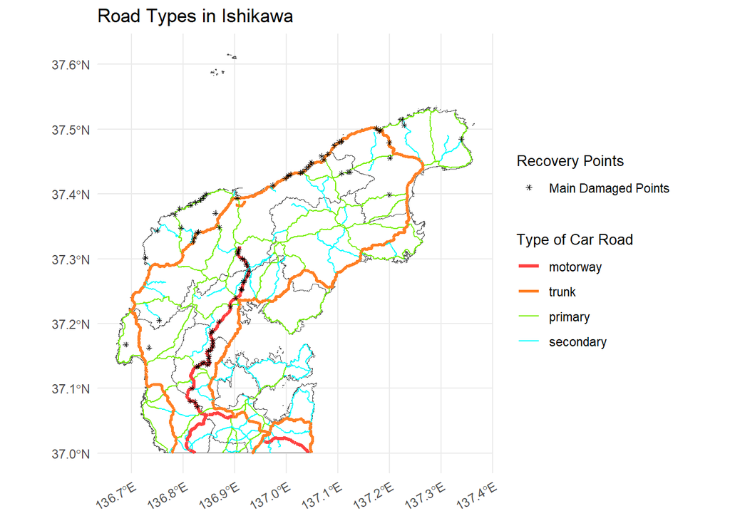

```r
# osm_car_roads and damaged points
f = factor(osm_car_roads$fclass,
           levels = c("motorway", "trunk", "primary","secondary"))
linewidth = c("motorway" = 1.2, "trunk" = 1, "primary" = 0.5, "secondary" = 0.5)
color = c("motorway" = "brown1", "trunk" = "chocolate1", "primary" = "chartreuse2","secondary" = "cyan")

ggplot() +
  geom_sf(data = la_cropped, fill = "grey100") +
  geom_sf(data = osm_car_roads, aes(col = f, linewidth  = f)) +
  geom_sf(data = all_recovery_point_sf,
          aes(shape = "Main Damaged Points"), size = 1) +
  scale_linewidth_manual(values = linewidth) +
  scale_color_manual(values = color) +
  scale_shape_manual(name = "Recovery Points",
                     values = c("Main Damaged Points" = 8)) +
  theme_minimal() +
  ggtitle("Road Types in Ishikawa") +
  guides(
    color = guide_legend(title = "Type of Car Road"),
    linewidth = guide_legend(title = "Type of Car Road"),
    shape = guide_legend(title = "Recovery Points")
  ) +
  theme(legend.title = element_text(size = 10)) +
  theme(axis.text.x = element_text(angle = 30, hjust = 1))
```

## 2.3 Identification of Critical Nodes

Centralities are introduced to identify important nodes in the road network. The degree, betweenness, and closeness centrality of each node are calculated and mapped to compare the three recovery stages and normal times. The nodes with high values of centralities could describe the critical nodes that we should strengthen and restore quickly to deliver relief distribution after disasters.

## 2.4 Calculation of Network Resilience

To analyze the network vulnerability with interrupted edges, we utilize network resilience that has been introduced to previous studies of transportation network analysis (Taghizadeh et al., 2023; Shen, 2024) Basically, network resilience represents the proportion of recovery at time (t) to total loss at some previous time (td), shown as follows (Henry, 2012);
$$R(t) = \frac{\text{Recovery}(t)}{\text{Loss}(t_d)}$$
In this study, the normal times data (OSM road data) is used to compare with recovery because the data of the total loss was not available. Some indices describing network performance are calculated to examine the ratio of recovery to the original ones. To evaluate the resilience of this network, the below indices were introduced by using “igraph” package;

| **Performance Indices** | **Purpose** |
| --- | --- |
| **Component** | To identify isolated components |
| **Average Shortest Path Length** | To measure how efficient it is to move between nodes |
| **Redundancy of Links (Edge Density)** | To evaluate whether alternative paths are available |
| **Network Efficiency** | To evaluate the efficiency, like Average Shortest Path Length |
| **Average Centralities** (Degree, Betweenness, and Closeness) | To examine the features of nodes |

The changes in these performance indices over time are compared between three recovery phases and between different calculation methods.

## 2.5 Algorithm for Resilience Analysis

We also assess network resilience and performance using three node-failure patterns: Random, the breadth-first search (BFS) tree and the depth-first search (DFS) tree, compared to the case study. BFS and DFS are often used in the context of graph traversal. (Jiang, 1990) This study uses these algorithms to predict the closure of road paths, which aims to evaluate whether these algorithms can predict road damage and the status of the road during disasters.

# 3 Result and Discussion

## 3.1 Identification of Critical Nodes

### 3.1.1 Preparing data

To calculate centralities (Degree, Betweenness, Closeness, Eigenvector, and PageRank) at each phase, we prepare the dataset as sf network objects.

#### 3.1.1.1 Recovery Phases

```r
# Network centralities of recovery data
daily_centrality_list <- all_restored_road_sf %>%
  mutate(date = Date) %>%                   # duplicate the date column to leave the date data
  group_by(date) %>%
  group_map(~ {
    network <- as_sfnetwork(.x) %>%
      activate("nodes") %>%
      mutate(degree = degree(.),            # calculate the centrality
             betweenness = betweenness(.),
             closeness = closeness(.),
             eigenvector = eigen_centrality(.)$vector,
             pagerank = page_rank(.)$vector)

    st_set_crs(network, 4326)
    network   # return the network data
  })
names(daily_centrality_list) <- unique(all_restored_road_sf$Date)
head(daily_centrality_list, n = 1)
```

```
## $`2024-01-12`
## # A sfnetwork with 478 nodes and 245 edges
## #
## # CRS:  WGS 84
## #
## # A rooted forest with 233 trees with spatially explicit edges
## #
## # A tibble: 478 × 6
##              geometry degree betweenness closeness eigenvector pagerank
##           <POINT [°]>  <dbl>       <dbl>     <dbl>       <dbl>    <dbl>
## 1 (136.8707 37.14251)      1           0         1    8.78e-17  0.00145
## 2 (136.8711 37.14362)      1           0       NaN    1.32e-16  0.00267
## 3 (136.8711 37.14362)      1           0         1    1.10e-16  0.00145
## 4 (136.8766 37.14912)      1           0       NaN    4.39e-17  0.00267
## 5  (136.8703 37.1422)      1           0         1    0         0.00145
## 6 (136.8826 37.16123)      1           0       NaN    0         0.00267
## # ℹ 472 more rows
## #
## # A tibble: 245 × 5
##    from    to length Date                                               geometry
##   <int> <int>  <dbl> <date>                                     <LINESTRING [°]>
## 1     1     2     NA 2024-01-12           (136.8707 37.14251, 136.8711 37.14362)
## 2     3     4     NA 2024-01-12 (136.8711 37.14362, 136.871 37.14379, 136.8709 …
## 3     5     6     NA 2024-01-12 (136.8703 37.1422, 136.8689 37.14332, 136.8686 …
## # ℹ 242 more rows
```

#### 3.1.1.2 Normal Times

```r
# Network centralities of normal times
normal_centrality <- osm_car_roads %>%
  as_sfnetwork() %>%
  activate("nodes") %>%
  mutate(degree = degree(.),
         betweenness = betweenness(.),
         closeness = closeness(.),
         eigenvector = eigen_centrality(.)$vector,
         pagerank = page_rank(.)$vector)

normal_centrality
```

```
## # A sfnetwork with 1972 nodes and 1951 edges
## #
## # CRS:  WGS 84
## #
## # A directed multigraph with 49 components with spatially explicit edges
## #
## # A tibble: 1,972 × 6
##              geometry degree betweenness closeness eigenvector pagerank
##           <POINT [°]>  <dbl>       <dbl>     <dbl>       <dbl>    <dbl>
## 1  (136.951 37.09822)      2         391   0.00885    2.89e-15 0.000736
## 2 (136.9459 37.09263)      2         384   0.0104     6.36e-15 0.000734
## 3  (136.938 37.08525)      2         375   0.0125     1.49e-14 0.000732
## 4 (136.9212 37.07633)      4        1050   0.0154     3.44e-14 0.00141
## 5 (136.9556 37.05293)      2         986   0.00211    8.67e- 9 0.000576
## 6 (136.9527 37.05673)      2         990   0.00227    3.72e- 9 0.000598
## # ℹ 1,966 more rows
## #
## # A tibble: 1,951 × 13
##    from    to osm_id    code fclass  name    ref   oneway maxspeed layer bridge
##   <int> <int> <chr>    <int> <chr>   <chr>   <chr> <chr>     <int> <dbl> <chr>
## 1     1     2 25807756  5113 primary 石川県… 47    B            50     0 F
## 2     3     4 25808566  5113 primary 石川県… 47    B            40     0 F
## 3     2     3 25808599  5113 primary 能登島… 47    B             0     0 T
## # ℹ 1,948 more rows
## # ℹ 2 more variables: tunnel <chr>, geometry <LINESTRING [°]>
```

To examine the relationship of the five centralities in this road, the correlogram is provided below.

```r
cor.mat <- normal_centrality %>%
  as_tibble() %>%
  st_drop_geometry() %>%
  cor(use = "complete.obs")  # exclude NA rows

cor.mat
```

```
##                 degree betweenness   closeness eigenvector    pagerank
## degree       1.0000000   0.1288869 -0.14848379  0.16547554  0.43836057
## betweenness  0.1288869   1.0000000 -0.17398734 -0.02689130  0.34048207
## closeness   -0.1484838  -0.1739873  1.00000000 -0.03224087 -0.14839734
## eigenvector  0.1654755  -0.0268913 -0.03224087  1.00000000  0.04033439
## pagerank     0.4383606   0.3404821 -0.14839734  0.04033439  1.00000000
```

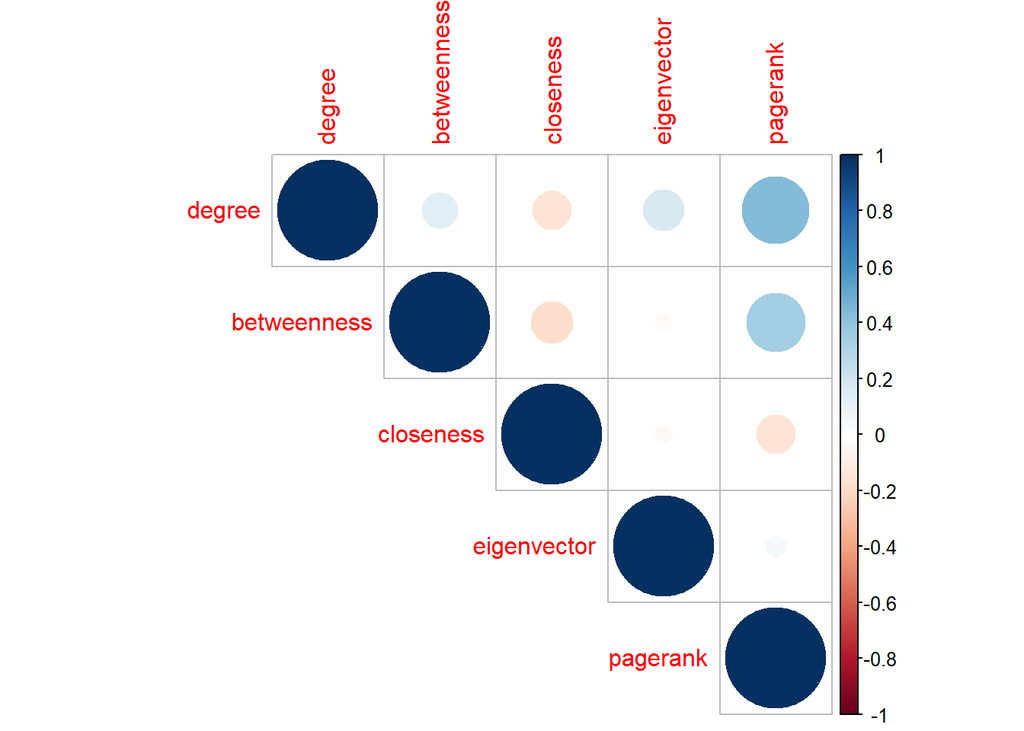

```r
corrplot(cor.mat, type="upper")
```

The graph shows positive correlations between Degree and PageRank, and Betweenness and PageRank. On the other hand, Closeness has negative relationships with other indices and Eigenvector did not show clear correlations with others. Considering the distinction of the Closeness, an increase in connectivity and the number of intermediate points would not imply high efficiency in transportation in this road network. In the following analysis, we focus on the three indices: Degree, Betweenness, and Closeness, due to the clear differences of these features.

### 3.1.2 Mapping Centralities

#### 3.1.2.1 Preparing the data

```r
# combine the recovery and normal data
daily_centrality_list$`Normal` = normal_centrality

# extract only centralites as a tibble object
cetrality_tibble_list <- daily_centrality_list %>%
  lapply(function(x){
    as_tibble(x)
  })

# extract only edge data for mapping
edge_list <- daily_centrality_list %>%
  lapply(function(x){
    st_as_sf(x, "edges")
  })

# define indices of 4 stages
selected_dates = c("2024-01-12", "2024-01-19", "2024-09-25", "Normal")
stages = c("Early-stage", "Mid-stage", "Last-stage", "Noraml times")
```

```r
# prepare a ggplot adjustment
option <- theme_minimal() +
  theme(legend.position = "bottom",
        legend.direction = "horizontal",
        legend.title = element_blank()) +
  theme(axis.text.x = element_text(angle = 30, hjust = 1, size = 6))
```

#### 3.1.2.2 Degree

Next, we check Degree centralities to identify the important nodes in terms of connectivity and traffic flows.

```r
# degree ----
col = viridis(4, option = "D", begin  = 0.2, end = 1)  # make a color pallet
selected_dates = c("2024-01-12", "2024-01-19", "2024-09-25", "Normal")
d = list()

for(i in 1:4){
  dat = cetrality_tibble_list[selected_dates[i]] %>% bind_rows
  road = edge_list[selected_dates[i]] %>% bind_rows

    if(i == 4){
    col_value <- c("1" = col[1], "2" = col[2], "3" = col[3], "4" = col[4])
    size_value <- c("1" = 0.2, "2" = 0.8, "3" = 1.3, "4" = 2)
  } else{
    col_value <- c("1" = col[1], "2" = col[2])
    size_value <- c("1" = 0.7, "2" = 2)
  }

  d[[i]] <- ggplot() +
    geom_sf(data = la_cropped, fill = "grey100") +
    geom_sf(data = road, color = "grey", linewidth = 0.3) +
    geom_sf(data = dat, aes(col = factor(degree), size = factor(degree))) +
    ggtitle(paste0(stages[i], " Degree")) +
    scale_color_manual(values = col_value) +
    scale_size_manual(values = size_value) +
    option
    # scale_color_brewer(limits = c(1,2,3,4)) +
    # scale_color_hue(limits = c(1,2,3,4)) +
}
```

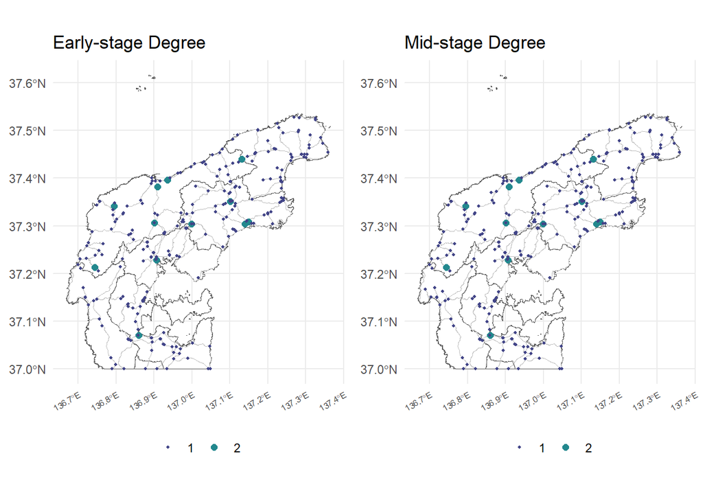

```r
# plot
plot_grid(d[[1]], d[[2]], ncol = 2)
```

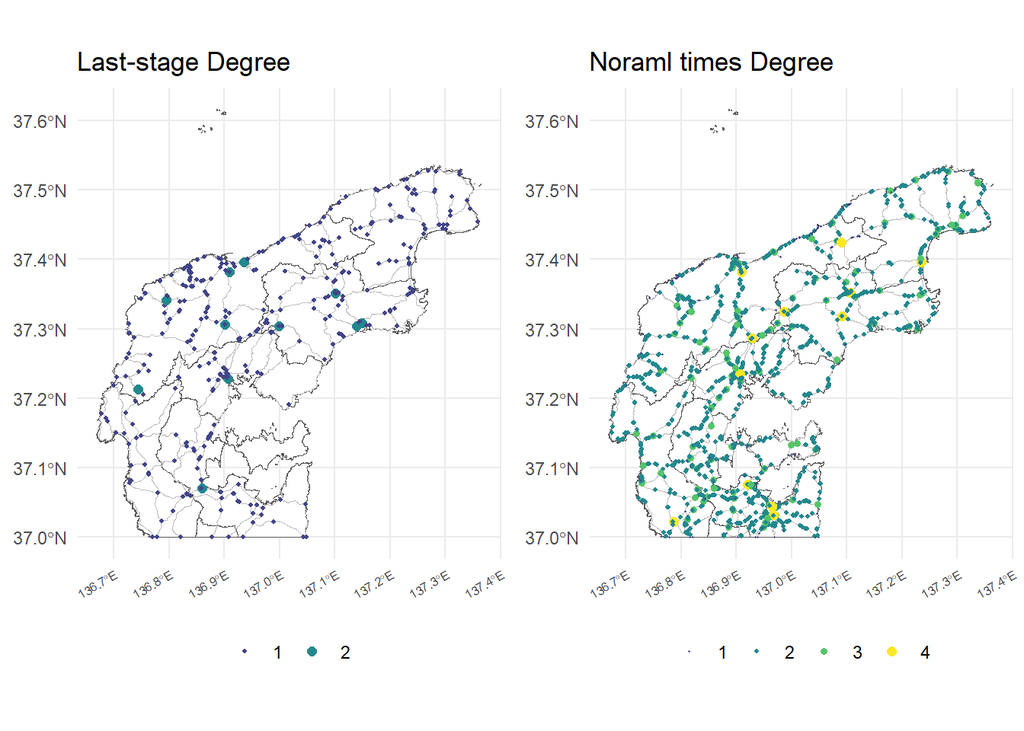

```r
plot_grid(d[[3]], d[[4]], ncol = 2)
```

In normal times, the yellow plots represent the critical nodes, which are located mostly in the interior. These areas with high value of the Degree can be thought to be important towns where the flow of people and goods is active. In comparison to the normal road status, the nodes around (37.3°N, 136.9°E) in the recovery phases show lower Degree values. It is proposed that the area did not function as usual after the earthquake happened. Furthermore, the degree in the southern part, which is an entrance of the peninsula, decreased dramatically, which can describe the difficulties in the delivery of goods and people for aid. The differences between the Early-stage and Mid-stage cannot be seen in the maps, but nodes around (37.37N, 136.80°E) were repaired considerably at the Last-stage.

#### 3.1.2.3 Betweenness

Following the degree analysis, we measure the betweenness at multiple phases to evaluate the intermediate points in this road network.

```r
# betweenness ----
selected_dates = c("2024-01-12", "2024-01-19", "2024-09-25", "Normal")
b = list()
for(i in 1:4){
  dat = cetrality_tibble_list[selected_dates[i]] %>% bind_rows
  road = edge_list[selected_dates[i]] %>% bind_rows

  if(i == 4){
    # separate betweenness into 4
    breaks <- quantile(dat$betweenness, probs = seq(0, 1, by = 0.25))
    rounded_breaks <- round(breaks, -1)
    labels <- paste0(head(rounded_breaks, -1), " - ", tail(rounded_breaks, -1))
    dat$betweenness_cat <- cut(dat$betweenness,
                               breaks = rounded_breaks,
                               labels = labels)
  } else{
    # recovery data have only 0 or 1 betweenness
    dat$betweenness_cat <- factor(dat$betweenness, level = c(0,1))
  }


  b[[i]] <- ggplot() +
    geom_sf(data = la_cropped, fill = "grey100") +
    geom_sf(data = road, color = "grey", linewidth = 0.3) +
    geom_sf(data = dat, aes(col = betweenness_cat, size = betweenness_cat)) +
    ggtitle(paste0(stages[i], " Betweenness")) +
    scale_color_viridis_d(begin  = 0.2, end = 1) +
    scale_size_discrete(range = c(0.5, 2)) +
    option
}
```

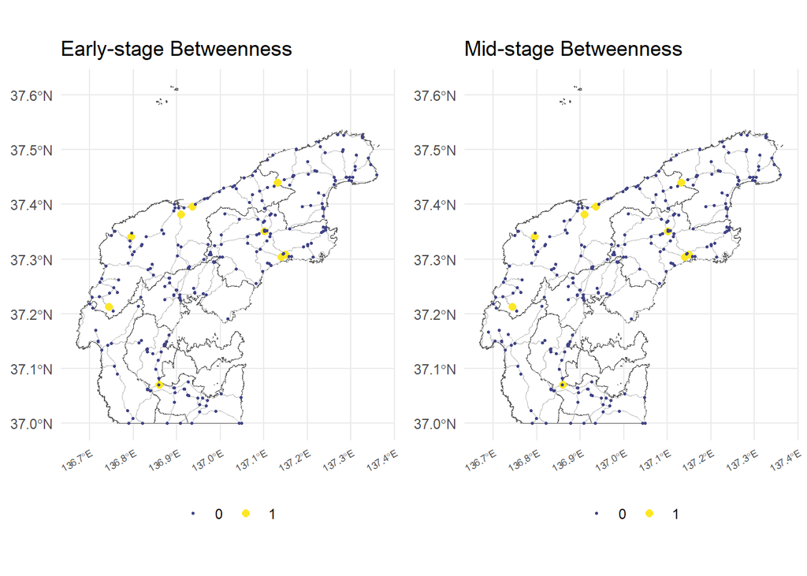

```r
plot_grid(b[[1]], b[[2]], ncol = 2)
```

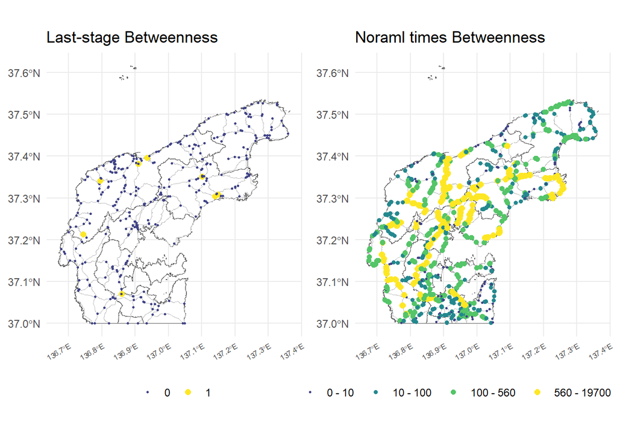

```r
plot_grid(b[[3]], b[[4]], ncol = 2)
```

Normally, there are some nodes with betweenness above 1000 along the multiple roads, which are considered to be prime car roads. On the other hand, many edges during recovery phases show 0 betweenness, and the points with 1 betweenness do not necessarily correspond to the higher betweenness nodes in normal times. It describes that the restored roads might consist of many isolated nodes and there are no alternative roads.

#### 3.1.2.4 Closeness

```r
# closeness ----
selected_dates = c("2024-01-12", "2024-01-19", "2024-09-25", "Normal")
col = viridis(4, option = "D", begin  = 0.1, end = 1) # make a color pallet
c = list()
for(i in 1:4){
  dat = cetrality_tibble_list[selected_dates[i]] %>% bind_rows
  road = edge_list[selected_dates[i]] %>% bind_rows

  # split into normal and recovery cases to create color and size scales
  if(i == 4){
    n = 2 # set the legend row number
    # separate closeness into 5 including NA
    breaks <- quantile(dat$closeness[!is.na(dat$closeness)],
                       probs = seq(0, 1, by = 0.25))
    rounded_breaks <- round(breaks, 3)
    labels <- paste0(head(rounded_breaks, -1), " - ", tail(rounded_breaks, -1))

    dat$closeness_cat <- cut(dat$closeness,
                             breaks = rounded_breaks,
                             labels = labels)
    # treat NaN value as isolated nodes
    dat$closeness_cat <- factor(dat$closeness_cat, levels = c(levels(dat$closeness_cat), "no_value"))
    dat$closeness_cat[is.na(dat$closeness_cat)] <- "no_value"

    # define the color
    col <- c(viridis(4, option = "D", begin  = 0.1, end = 1), "brown1")
    col_value <- setNames(col, c(levels(dat$closeness_cat)))
    # define the size
    size <- c(0.7, 1, 1.2, 1.5, 0.5)
    size_value <- setNames(size, c(levels(dat$closeness_cat)))

  } else{
    n = 1 # set the legend row number

    dat$closeness_round <- round(dat$closeness, 1)
    dat$closeness_round[is.na(dat$closeness_round)] <- NA # conver NaN to NA

    dat$closeness_cat <- factor(dat$closeness_round)
    dat$closeness_cat <- factor(dat$closeness_cat,
                                levels = c(levels(dat$closeness_cat), "no_value"))
    dat$closeness_cat[is.na(dat$closeness_cat)] <- "no_value"

    # define the color
    col <- c(viridis(3, option = "D", begin  = 0.1, end = 1), "brown1")
    col_value <- setNames(col, c(levels(dat$closeness_cat)))
    # define the size
    size <-  c(0.4, 0.7, 1, 0.5)
    size_value <- setNames(size, c(levels(dat$closeness_cat)))
  }

  c[[i]] <- ggplot() +
    geom_sf(data = la_cropped, fill = "grey100") +
    geom_sf(data = road, color = "grey", linewidth = 0.3) +
    geom_sf(data = dat, aes(col = closeness_cat, size = closeness_cat)) +
    ggtitle(paste0(stages[i], " Closeness")) +
    scale_color_manual(values = col_value) +
    scale_size_manual(values = size_value) +
    option +
    guides(color = guide_legend(nrow = n))
}
```

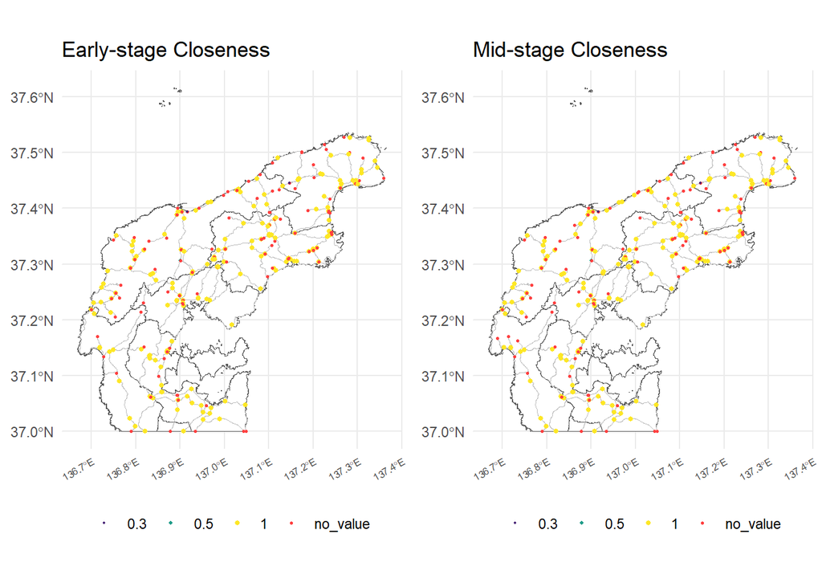

```r
plot_grid(c[[1]], c[[2]], ncol = 2)
```

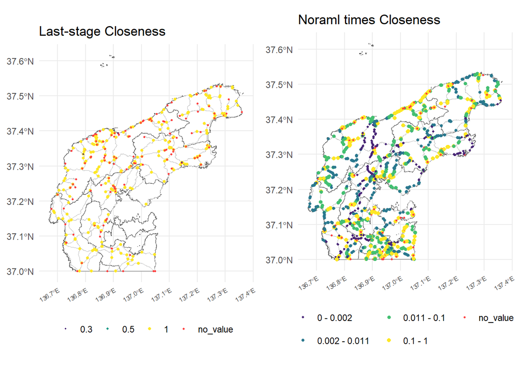

```r
plot_grid(c[[3]], c[[4]], ncol = 2)
```

Overall, the result shows many isolated or short paths during recovery phases and implies a great impact of the disaster on the region. High degree points represent some central area and high betweenness describes that the region basically does not have enough alternative roads to access each town. It implies that critical paths with high betweenness require to be strengthened regularly.

## 3.2 Resilience of Case Study

### 3.2.1 Preparing the `sf` object of four phases

Resilience is measured by comparing the changes in some network performance indices over time with those in the original status. Initially, we create the dataset including the road networks at three recovery phases (early, mid, and last stages) and in normal times. At this point, the road type (`fclass`) and `osm_id` provided by the osm dataset can be incorporated into the restored road data by identifying the same geometry in the osm road.

```r
# normal times data
normal <- osm_car_roads %>%
  mutate(Stage = "Normal times") %>%     # add Stage column to match to recovery data
  select(osm_id, Stage, fclass, geometry)

# recovery data (only 3 days)
selected_dates <- as.character(selected_dates[-4])
all_restored_road_sf$Date  <- as.character(all_restored_road_sf$Date) # convert Date into character class

selected_recovery <- all_restored_road_sf %>%
  filter(Date %in% selected_dates)  %>%
  mutate(Date = recode(Date,
                      `2024-01-12` = "Early-stage",
                      `2024-01-19` = "Mid-stage",
                      `2024-09-25` = "Last-stage"))  %>%
  dplyr::rename(Stage = Date)

# find the osm_id and fcalss (road type) from normal times data
recovery_fclass <- st_join(selected_recovery, normal[, c("osm_id", "fclass")]) %>%  # join based on geometry
  distinct(Stage, geometry, .keep_all = TRUE) %>%                                   # remove the duplicates rows
  mutate(fclass = ifelse(is.na(fclass), "unclassified", fclass),) %>%               # label unclassified data
  select(osm_id, Stage, fclass, geometry)

# combine the two data
road_sf <- rbind(recovery_fclass, normal)
stages <- c("Early-stage", "Mid-stage", "Last-stage", "Normal times")

# covert osm_id into numeric
road_sf$osm_id <- as.numeric(road_sf$osm_id)

head(road_sf)
```

```
## Simple feature collection with 6 features and 3 fields
## Geometry type: LINESTRING
## Dimension:     XY
## Bounding box:  xmin: 136.8686 ymin: 37.14216 xmax: 136.9159 ymax: 37.39444
## Geodetic CRS:  WGS 84
##      osm_id       Stage       fclass                       geometry
## 1        NA Early-stage unclassified LINESTRING (136.8707 37.142...
## 2        NA Early-stage unclassified LINESTRING (136.8711 37.143...
## 3 156598584 Early-stage        trunk LINESTRING (136.8703 37.142...
## 4 731921909 Early-stage    secondary LINESTRING (136.8722 37.144...
## 5 127875374 Early-stage        trunk LINESTRING (136.8928 37.388...
## 6 399825820 Early-stage        trunk LINESTRING (136.9046 37.393...
```

```r
# convert data into LINESTRING for resilience analysis
geom_types <- st_geometry_type(road_sf)
road_lines_sf <- road_sf[geom_types != "POINT", ] # remove point data
road_lines_sf <- st_cast(road_lines_sf, "LINESTRING") # convert into LINESTRING
```

### 3.2.2 Calculation of Performance Indices

Each index is calculated in the below code. `avg_shortest_path` could not be measured using the `igraph` package because there are many unreachable nodes, and the `dodgr` package (Padgham, 2019) is introduced to this analysis and calculates the weighted distances.

```r
# define a function for the calculation of performance indices
performance_calculation <- function(st){
  # filter the road by stages
  sf <- road_lines_sf %>%
    filter(Stage == st)
  g <- sf %>%
    as_sfnetwork()

  # calculations
  n_nodes = gorder(g) # number of nodes
  n_edges = gsize(g)  # number of edges

  ## 1. Components
  components <- components(g)
  n_components <- components$no

  ## 2. Average Shortest Path (Weighted)
  dodgr <- weight_streetnet(sf,
                            type_col = "fclass",
                            wt_profile = "motorcar",
                            id_col = "osm_id")
  avg_shortest_path <- mean(dodgr$d_weighted)

  ## 3. Edge Density
  edge_density <- edge_density(g)

  ## 4. Network Efficiency
  network_efficiency <- 1 / avg_shortest_path

  ## 5. Average Centralities
  avg_degree <- mean(degree(g))
  avg_betweenness <- mean(betweenness(g))
  avg_closeness <- mean(closeness(g), na.rm = TRUE)

  result <- cbind(st,
                  n_nodes, n_edges,
                  n_components,
                  avg_shortest_path ,
                  edge_density,
                  network_efficiency,
                  avg_degree, avg_betweenness, avg_closeness)

  return(result)
}

performance <- rbind(performance_calculation(stages[1]),
           performance_calculation(stages[2]),
           performance_calculation(stages[3]),
           performance_calculation(stages[4]))

performance <- performance %>%
  as.data.frame() %>%
  mutate_at(vars(-1), as.numeric)

performance %>%
  kable(caption = "Performance") %>%
  column_spec(1:ncol(performance),
              extra_css = "padding-left: 30px; padding-right: 30px;") %>%
  scroll_box(width = "180%", height = "200px")
```

Performance

| st | n_nodes | n_edges | n_components | avg_shortest_path | edge_density | network_efficiency | avg_degree | avg_betweenness | avg_closeness |
| --- | --- | --- | --- | --- | --- | --- | --- | --- | --- |
| Early-stage | 478 | 245 | 233 | 45.73178 | 0.0010745 | 0.0218666 | 1.025105 | 0.0188285 | 0.9733607 |
| Mid-stage | 488 | 250 | 238 | 45.96543 | 0.0010519 | 0.0217555 | 1.024590 | 0.0184426 | 0.9738956 |
| Last-stage | 649 | 330 | 319 | 46.58064 | 0.0007847 | 0.0214681 | 1.016949 | 0.0123267 | 0.9822695 |
| Normal times | 1972 | 1951 | 49 | 34.26672 | 0.0005020 | 0.0291828 | 1.978702 | 882.6369168 | 0.1327314 |

### 3.2.3 Calculation of Resilience

```r
normal_performance <- unlist(performance[4,-1])
resilience <- sweep(performance[1:3, -1], 2, normal_performance, FUN="/")

resilience_result <- data.frame(Stage = stages[1:3], resilience)

resilience_result %>%
  kable(caption = "Resilience") %>%
  column_spec(1:ncol(resilience_result),
              extra_css = "padding-left: 30px; padding-right: 30px;") %>%
  scroll_box(width = "180%", height = "200px")
```

Resilience

| Stage | n_nodes | n_edges | n_components | avg_shortest_path | edge_density | network_efficiency | avg_degree | avg_betweenness | avg_closeness |
| --- | --- | --- | --- | --- | --- | --- | --- | --- | --- |
| Early-stage | 0.2423935 | 0.1255766 | 4.755102 | 1.334583 | 2.140701 | 0.7492979 | 0.5180693 | 2.13e-05 | 7.333310 |
| Mid-stage | 0.2474645 | 0.1281394 | 4.857143 | 1.341401 | 2.095692 | 0.7454890 | 0.5178093 | 2.09e-05 | 7.337340 |
| Last-stage | 0.3291075 | 0.1691440 | 6.510204 | 1.359355 | 1.563257 | 0.7356430 | 0.5139476 | 1.40e-05 | 7.400429 |

The resilience was calculated by ratio to the performance in normal times and, in this table, we can examine the change in each index over the restored phase. Basically, an increase in the number of edges results in an increase in efficiency with a shorter minimum path length and connectivity with high centralities and fewer isolated edges. However, in this case, all indices demonstrated contrary patterns to expectations of better road performance. The efficiency of the road (`avg_shortest_path`, and `edge_efficiency`) show slight decreases, and increases in `n_components` and declines in `edge_density` and centralities describe the setback in the connectivity in this region. It is implied that partial restorations exacerbated the length of respective roads and the importance of the individual nodes.

### 3.2.4 Mapping the road

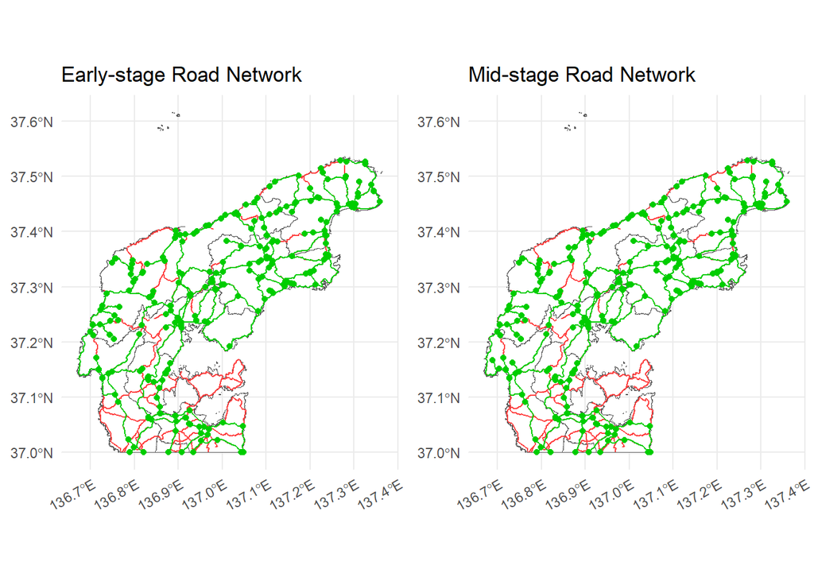

```r
g <- list()
for(i in 1:3){
  dat = road_lines_sf %>%
  filter(Stage == stages[i]) %>%
  as_sfnetwork()

  g[[i]] <- ggplot() +
    geom_sf(data = la_cropped, fill = "grey100") +
    geom_sf(data = osm_car_roads, aes(color = "Normal times")) +
    geom_sf(data = st_as_sf(dat, "edges"), aes(color = "Restored")) +  # plot edges
    geom_sf(data = st_as_sf(dat, "nodes"), aes(color = "Restored")) +  # plot nodes
    ggtitle(paste0(stages[i], " Road Network")) +
    theme_minimal() +
    # theme(legend.position = "none") +
    scale_color_manual(name = "Road", values = c("Normal times" = "brown1", "Restored" = "green3")) +
    theme(axis.text.x = element_text(angle = 30, hjust = 1)) +
    theme(legend.position = "none")
}

legend <- get_legend(
  ggplot() +
    geom_sf(data = la_cropped, fill = "grey100") +
    geom_sf(data = osm_car_roads, aes(color = "Normal times")) +
    geom_sf(data = st_as_sf(dat, "edges"), aes(color = "Restored")) +  # plot edges
    geom_sf(data = st_as_sf(dat, "nodes"), aes(color = "Restored")) +  # plot nodes
    ggtitle(paste0(stages[i], " Road Network")) +
    theme_minimal() +
    # theme(legend.position = "none") +
    scale_color_manual(name = "Road", values = c("Normal times" = "brown1", "Restored" = "green3")) +
    theme(axis.text.x = element_text(angle = 30, hjust = 1))
)

plot_grid(g[[1]], g[[2]], ncol = 2)
```

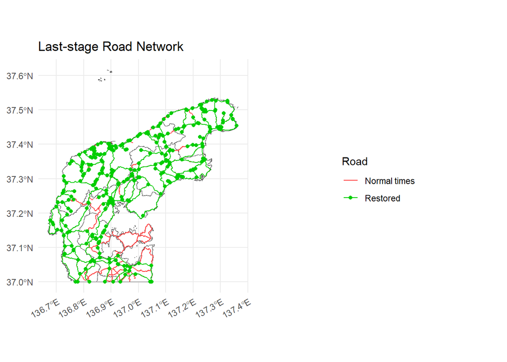

```r
plot_grid(g[[3]], legend, ncol = 2)
```

To sum up, it is suggested that the effectivity and the connectivity declined because the increase in short paths and isolated nodes reduced the short average length and component. It was observed that the restoration after disasters was carried out partially in this case. However, we must consider the differences in the resources of restored road data provided by MLIT Japan and the OSM data. The recovery data might not contain all available road paths because they focused on repaired roads, and it is also possible that the OSM data was extracted from four types of roads that ignored some local roads.

## 3.3 Resilience by Using Algorithms

Following the case study, three methods are incorporated to predict road performance while some edges are disrupted due to certain factors such as disasters.

### 3.3.1 Preparation of Data

```r
# Convert the road network into an igraph object
road_graph <- osm_car_roads %>%
  as_sfnetwork() %>%
  as.igraph()

# calculation of the number of removed edges in the case study
performance$n_edges <- as.numeric(performance$n_edges)
performance$n_edges[4] - performance$n_edges[1] # [1] 1706
```

```
## [1] 1706
```

```r
performance$n_edges[4] - performance$n_edges[2] # [1] 1701
```

```
## [1] 1701
```

```r
performance$n_edges[4] - performance$n_edges[3] # [1] 1621
```

```
## [1] 1621
```

```r
# define a function for the calculation of performance indices
al_performance_calculation <- function(g){
  sf = g %>%
    activate("edges") %>%
    st_as_sf()

  # calculations
  n_nodes = gorder(g) # number of nodes
  n_edges = gsize(g)  # number of edges

  ## 1. Components
  components <- components(g)
  n_components <- components$no

  ## 2. Average Shortest Path (Weighted)
  dodgr <- weight_streetnet(sf,
                            type_col = "fclass",
                            wt_profile = "motorcar",
                            id_col = "osm_id")
  avg_shortest_path <- mean(dodgr$d_weighted)

  ## 3. Edge Density
  edge_density <- edge_density(g)

  ## 4. Network Efficiency
  network_efficiency <- 1 / avg_shortest_path

  ## 5. Average Centralities
  avg_degree <- mean(degree(g))
  avg_betweenness <- mean(betweenness(g))
  avg_closeness <- mean(closeness(g), na.rm = TRUE)

  result <- cbind(n_nodes, n_edges,
                  n_components,
                  avg_shortest_path,
                  edge_density,
                  network_efficiency,
                  avg_degree, avg_betweenness, avg_closeness)

  return(result)
}
```

#### 3.3.1.1 Random

The sample size was set as 5 to examine the accuracy of the prediction, and the number of edges to be eliminated ranged from 1500 to 1700 considering the case study.

```r
set.seed(55)

num_edges_to_remove <- sample(1500:1700, 5)
p_random <- list()
random <- data.frame()

for(i in 1:5){
  # randomly select edges to remove
  random_edges <- sample(E(road_graph), num_edges_to_remove[i])

  # remove the selected edges
  random_removed_graph <- delete_edges(road_graph, random_edges)

  # plot the road after the interrupt
  random_removed_graph <- as_sfnetwork(random_removed_graph)

  p_random[[i]] <- ggplot() +
    geom_sf(data = osm_car_roads, aes(color = "Normal times")) +
    geom_sf(data = st_as_sf(random_removed_graph, "edges"), aes(color = "Restored")) +
    geom_sf(data = st_as_sf(random_removed_graph, "nodes"),
            aes(color = "Restored"),
            size = 0.3) +  # plot nodes
    ggtitle(paste0("Random Road Network")) +
    theme_minimal() +
    # theme(legend.position = "none") +
    scale_color_manual(name = "Road", values = c("Normal times" = "brown1", "Restored" = "green3")) +
    theme(axis.text.x = element_text(angle = 30, hjust = 1)) +
    theme(legend.position = "none")

  # calculation of performance
  dat <- al_performance_calculation(random_removed_graph)
  dat <- dat %>%
    data.frame() %>%
    mutate(Algorithm = "Random",
           removed_depth = num_edges_to_remove[i]) %>%
    select(Algorithm, removed_depth,
           n_nodes, n_edges,
           n_components, avg_shortest_path, edge_density, network_efficiency,
           avg_degree, avg_betweenness, avg_closeness)

  # create a dataframe
  random <- rbind(random, dat)
}
head(random)
```

```
##   Algorithm removed_depth n_nodes n_edges n_components avg_shortest_path
## 1    Random          1561    1972     390         1582          33.28570
## 2    Random          1662    1972     289         1683          32.51387
## 3    Random          1608    1972     343         1629          34.53465
## 4    Random          1500    1972     451         1521          33.88094
## 5    Random          1671    1972     280         1692          32.74167
##   edge_density network_efficiency avg_degree avg_betweenness avg_closeness
## 1 1.003393e-04         0.03004293  0.3955375      0.05578093     0.8517033
## 2 7.435399e-05         0.03075610  0.2931034      0.02789047     0.8982332
## 3 8.824713e-05         0.02895643  0.3478702      0.06997972     0.8552910
## 4 1.160334e-04         0.02951512  0.4574037      0.07403651     0.8444766
## 5 7.203847e-05         0.03054212  0.2839757      0.02281947     0.9111853
```

#### 3.3.1.2 BFS

In the BFS method, the depth of searching is set to be from 1500 to 1700 like the Random method, and the starting node is selected from the random 3 points

```r
set.seed(55)

bfs_depth <- sample(1500:1700, 5)
p_bfs <- list()
bfs <- data.frame()

for(i in 1:5){
  # start the BFS from a random node
  start_node <- sample(V(road_graph), 3)
  bfs_result <- bfs(road_graph, root = start_node, order = TRUE)

  # simulate an interrupt by eliminating edges at a random depth level
  edges_to_remove_bfs <- E(road_graph)[.from(bfs_result$order[bfs_result$order <= bfs_depth[i]])]
  bfs_removed_graph <- delete_edges(road_graph, edges_to_remove_bfs)

  # Plot the road after the interrupt
  bfs_removed_graph <- as_sfnetwork(bfs_removed_graph)
  p_bfs[[i]] <- ggplot() +
    geom_sf(data = osm_car_roads, aes(color = "Normal times")) +
    geom_sf(data = st_as_sf(bfs_removed_graph, "edges"), aes(color = "Restored")) +
    geom_sf(data = st_as_sf(bfs_removed_graph, "nodes"),
            aes(color = "Restored"),
            size = 0.3) +  # plot nodes
    ggtitle(paste0("BFS Road Network")) +
    theme_minimal() +
    # theme(legend.position = "none") +
    scale_color_manual(name = "Road", values = c("Normal times" = "brown1", "Restored" = "green3")) +
    theme(axis.text.x = element_text(angle = 30, hjust = 1)) +
    theme(legend.position = "none")

  # calculation of performance
  dat <- al_performance_calculation(bfs_removed_graph)
  dat <- dat %>%
    data.frame() %>%
    mutate(Algorithm = "BFS",
           removed_depth = bfs_depth[i]) %>%
    select(Algorithm, removed_depth,
           n_nodes, n_edges,
           n_components, avg_shortest_path, edge_density, network_efficiency,
           avg_degree, avg_betweenness, avg_closeness)

  # create a dataframe
  bfs <- rbind(bfs, dat)
}
head(bfs)
```

```
##   Algorithm removed_depth n_nodes n_edges n_components avg_shortest_path
## 1       BFS          1561    1972     397         1576          30.34509
## 2       BFS          1662    1972     294         1679          28.03966
## 3       BFS          1608    1972     346         1627          29.26163
## 4       BFS          1500    1972     457         1516          30.56351
## 5       BFS          1671    1972     286         1687          27.98701
##   edge_density network_efficiency avg_degree avg_betweenness avg_closeness
## 1 1.021403e-04         0.03295426  0.4026369       1.2738337     0.4934264
## 2 7.564040e-05         0.03566377  0.2981744       0.5517241     0.5433154
## 3 8.901897e-05         0.03417445  0.3509128       1.0466531     0.5211393
## 4 1.175771e-04         0.03271876  0.4634888       1.7773834     0.4648051
## 5 7.358215e-05         0.03573087  0.2900609       0.5425963     0.5453936
```

#### 3.3.1.3 DFS

Similarly to BFS, the depth is set to be from 1500 to 1700.

```r
set.seed(55)

dfs_depth <- sample(1500:1700, 5)
p_dfs <- list()
dfs <- data.frame()

for(i in 1:5){
  # Start DFS from a random node
  start_node <- sample(V(road_graph), 3)
  dfs_result <- dfs(road_graph, root = start_node, order = TRUE)

  # simulate an interrupt
  edges_to_remove_dfs <- E(road_graph)[.from(dfs_result$order[dfs_result$order <= dfs_depth[i]])]
  dfs_removed_graph <- delete_edges(road_graph, edges_to_remove_dfs)

  # Plot the road after the interrupt
  dfs_removed_graph <- as_sfnetwork(dfs_removed_graph)
  p_dfs[[i]] <- ggplot() +
    geom_sf(data = osm_car_roads, aes(color = "Normal times")) +
    geom_sf(data = st_as_sf(dfs_removed_graph, "edges"), aes(color = "Restored")) +
    geom_sf(data = st_as_sf(dfs_removed_graph, "nodes"),
            aes(color = "Restored"),
            size = 0.3) +
    ggtitle(paste0("DFS Road Network")) +
    theme_minimal() +
    # theme(legend.position = "none") +
    scale_color_manual(name = "Road", values = c("Normal times" = "brown1", "Restored" = "green3")) +
    theme(axis.text.x = element_text(angle = 30, hjust = 1)) +
    theme(legend.position = "none")

  # calculation of performance
  dat <- al_performance_calculation(dfs_removed_graph)
  dat <- dat %>%
    data.frame() %>%
    mutate(Algorithm = "DFS",
           removed_depth = dfs_depth[i]) %>%
    select(Algorithm, removed_depth,
           n_nodes, n_edges,
           n_components, avg_shortest_path, edge_density, network_efficiency,
           avg_degree, avg_betweenness, avg_closeness)

  # create a dataframe
  dfs <- rbind(dfs, dat)
}
head(dfs)
```

```
##   Algorithm removed_depth n_nodes n_edges n_components avg_shortest_path
## 1       DFS          1561    1972     397         1576          30.34509
## 2       DFS          1662    1972     294         1679          28.03966
## 3       DFS          1608    1972     346         1627          29.26163
## 4       DFS          1500    1972     457         1516          30.56351
## 5       DFS          1671    1972     286         1687          27.98701
##   edge_density network_efficiency avg_degree avg_betweenness avg_closeness
## 1 1.021403e-04         0.03295426  0.4026369       1.2738337     0.4934264
## 2 7.564040e-05         0.03566377  0.2981744       0.5517241     0.5433154
## 3 8.901897e-05         0.03417445  0.3509128       1.0466531     0.5211393
## 4 1.175771e-04         0.03271876  0.4634888       1.7773834     0.4648051
## 5 7.358215e-05         0.03573087  0.2900609       0.5425963     0.5453936
```

#### 3.3.1.4 Combine Three Data

```r
algorithms <- c("Random", "BFS", "DFS")
al_performance <- rbind(random, bfs, dfs)

al_performance %>%
  kable(caption = "Performance") %>%
  column_spec(1:ncol(al_performance),
              extra_css = "padding-left: 30px; padding-right: 30px;") %>%
  scroll_box(width = "180%", height = "400px")
```

Performance

| Algorithm | removed_depth | n_nodes | n_edges | n_components | avg_shortest_path | edge_density | network_efficiency | avg_degree | avg_betweenness | avg_closeness |
| --- | --- | --- | --- | --- | --- | --- | --- | --- | --- | --- |
| Random | 1561 | 1972 | 390 | 1582 | 33.28570 | 0.0001003 | 0.0300429 | 0.3955375 | 0.0557809 | 0.8517033 |
| Random | 1662 | 1972 | 289 | 1683 | 32.51387 | 0.0000744 | 0.0307561 | 0.2931034 | 0.0278905 | 0.8982332 |
| Random | 1608 | 1972 | 343 | 1629 | 34.53465 | 0.0000882 | 0.0289564 | 0.3478702 | 0.0699797 | 0.8552910 |
| Random | 1500 | 1972 | 451 | 1521 | 33.88094 | 0.0001160 | 0.0295151 | 0.4574037 | 0.0740365 | 0.8444766 |
| Random | 1671 | 1972 | 280 | 1692 | 32.74167 | 0.0000720 | 0.0305421 | 0.2839757 | 0.0228195 | 0.9111853 |
| BFS | 1561 | 1972 | 397 | 1576 | 30.34509 | 0.0001021 | 0.0329543 | 0.4026369 | 1.2738337 | 0.4934264 |
| BFS | 1662 | 1972 | 294 | 1679 | 28.03966 | 0.0000756 | 0.0356638 | 0.2981744 | 0.5517241 | 0.5433154 |
| BFS | 1608 | 1972 | 346 | 1627 | 29.26163 | 0.0000890 | 0.0341744 | 0.3509128 | 1.0466531 | 0.5211393 |
| BFS | 1500 | 1972 | 457 | 1516 | 30.56351 | 0.0001176 | 0.0327188 | 0.4634888 | 1.7773834 | 0.4648051 |
| BFS | 1671 | 1972 | 286 | 1687 | 27.98701 | 0.0000736 | 0.0357309 | 0.2900609 | 0.5425963 | 0.5453936 |
| DFS | 1561 | 1972 | 397 | 1576 | 30.34509 | 0.0001021 | 0.0329543 | 0.4026369 | 1.2738337 | 0.4934264 |
| DFS | 1662 | 1972 | 294 | 1679 | 28.03966 | 0.0000756 | 0.0356638 | 0.2981744 | 0.5517241 | 0.5433154 |
| DFS | 1608 | 1972 | 346 | 1627 | 29.26163 | 0.0000890 | 0.0341744 | 0.3509128 | 1.0466531 | 0.5211393 |
| DFS | 1500 | 1972 | 457 | 1516 | 30.56351 | 0.0001176 | 0.0327188 | 0.4634888 | 1.7773834 | 0.4648051 |
| DFS | 1671 | 1972 | 286 | 1687 | 27.98701 | 0.0000736 | 0.0357309 | 0.2900609 | 0.5425963 | 0.5453936 |

We must consider that the number of nodes is constant because only edges were removed by the three methods

### 3.3.2 Calculation of Resilience

```r
normal_performance <- unlist(performance[4,-1])
al_resilience <- sweep(al_performance[, 3:11], 2, normal_performance, FUN="/")

al_resilience_result <- data.frame(al_performance[,1:2], al_resilience)

al_resilience_result %>%
  kable(caption = "Resilience") %>%
  column_spec(1:ncol(al_resilience_result),
              extra_css = "padding-left: 30px; padding-right: 30px;") %>%
  scroll_box(width = "180%", height = "400px")
```

Resilience

| Algorithm | removed_depth | n_nodes | n_edges | n_components | avg_shortest_path | edge_density | network_efficiency | avg_degree | avg_betweenness | avg_closeness |
| --- | --- | --- | --- | --- | --- | --- | --- | --- | --- | --- |
| Random | 1561 | 1 | 0.1998975 | 32.28571 | 0.9713710 | 0.1998975 | 1.029473 | 0.1998975 | 0.0000632 | 6.416742 |
| Random | 1662 | 1 | 0.1481292 | 34.34694 | 0.9488469 | 0.1481292 | 1.053911 | 0.1481292 | 0.0000316 | 6.767299 |
| Random | 1608 | 1 | 0.1758073 | 33.24490 | 1.0078187 | 0.1758073 | 0.992242 | 0.1758073 | 0.0000793 | 6.443772 |
| Random | 1500 | 1 | 0.2311635 | 31.04082 | 0.9887417 | 0.2311635 | 1.011386 | 0.2311635 | 0.0000839 | 6.362296 |
| Random | 1671 | 1 | 0.1435161 | 34.53061 | 0.9554947 | 0.1435161 | 1.046578 | 0.1435161 | 0.0000259 | 6.864880 |
| BFS | 1561 | 1 | 0.2034854 | 32.16327 | 0.8855558 | 0.2034854 | 1.129234 | 0.2034854 | 0.0014432 | 3.717480 |
| BFS | 1662 | 1 | 0.1506920 | 34.26531 | 0.8182767 | 0.1506920 | 1.222080 | 0.1506920 | 0.0006251 | 4.093344 |
| BFS | 1608 | 1 | 0.1773450 | 33.20408 | 0.8539371 | 0.1773450 | 1.171046 | 0.1773450 | 0.0011858 | 3.926269 |
| BFS | 1500 | 1 | 0.2342389 | 30.93878 | 0.8919297 | 0.2342389 | 1.121165 | 0.2342389 | 0.0020137 | 3.501847 |
| BFS | 1671 | 1 | 0.1465915 | 34.42857 | 0.8167400 | 0.1465915 | 1.224380 | 0.1465915 | 0.0006147 | 4.109001 |
| DFS | 1561 | 1 | 0.2034854 | 32.16327 | 0.8855558 | 0.2034854 | 1.129234 | 0.2034854 | 0.0014432 | 3.717480 |
| DFS | 1662 | 1 | 0.1506920 | 34.26531 | 0.8182767 | 0.1506920 | 1.222080 | 0.1506920 | 0.0006251 | 4.093344 |
| DFS | 1608 | 1 | 0.1773450 | 33.20408 | 0.8539371 | 0.1773450 | 1.171046 | 0.1773450 | 0.0011858 | 3.926269 |
| DFS | 1500 | 1 | 0.2342389 | 30.93878 | 0.8919297 | 0.2342389 | 1.121165 | 0.2342389 | 0.0020137 | 3.501847 |
| DFS | 1671 | 1 | 0.1465915 | 34.42857 | 0.8167400 | 0.1465915 | 1.224380 | 0.1465915 | 0.0006147 | 4.109001 |

### 3.3.3 Mapping the road

The three methods can depict the restored road map as below;

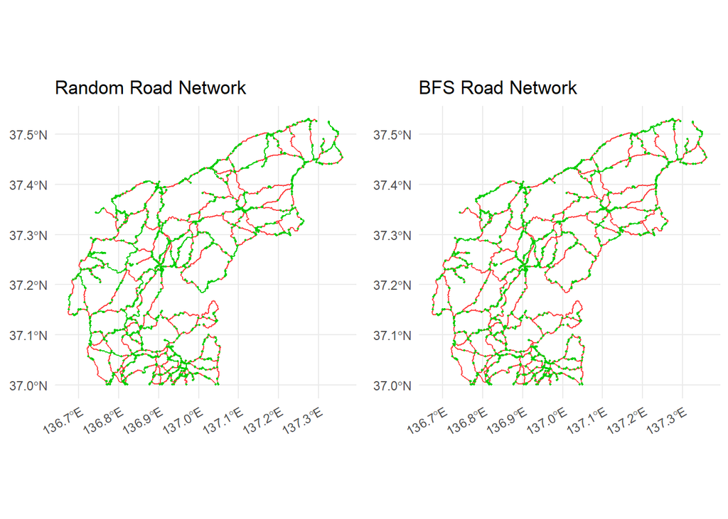

```r
legend <- get_legend(
  ggplot() +
    geom_sf(data = osm_car_roads, aes(color = "Normal times")) +
    geom_sf(data = st_as_sf(dfs_removed_graph, "edges"), aes(color = "Restored")) +
    geom_sf(data = st_as_sf(dfs_removed_graph, "nodes"),
            aes(color = "Restored"),
            size = 0.3) +
    scale_color_manual(name = "Road", values = c("Normal times" = "brown1", "Restored" = "green3"))
)


plot_grid(p_random[[1]], p_bfs[[2]], ncol = 2)
```

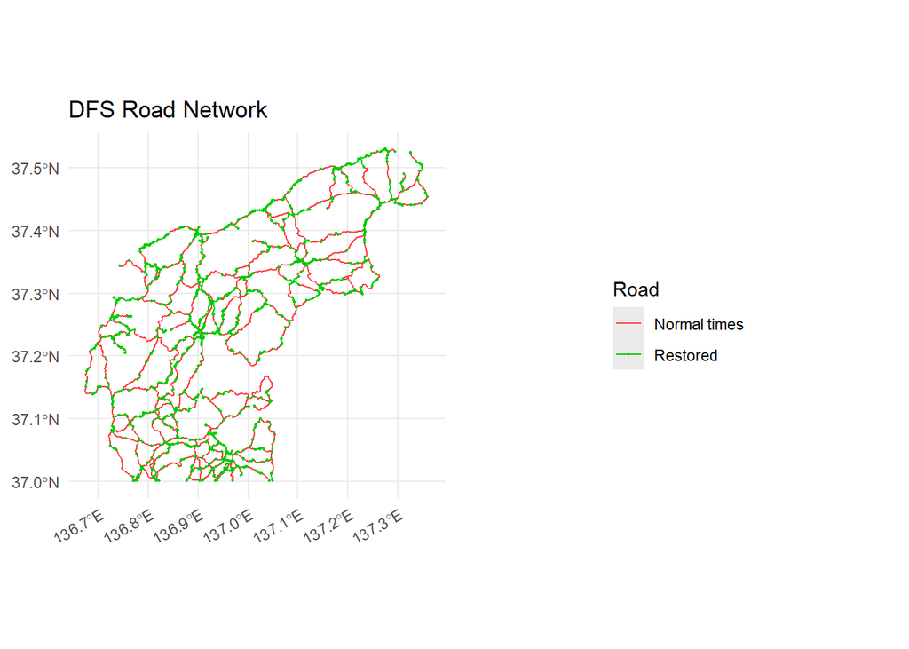

```r
plot_grid(p_dfs[[3]], legend, ncol = 2)
```

They do not explain significant differences between the algorithms in terms of the interrupt pattern.

## 3.4 Case Study vs. Algorithms

To examine the differences between all algorithms and the case study, each performance in response to the proportion of the repaired edges is plotted below.

```r
case <- resilience_result %>%
  mutate(type = "Case Study") %>%
  select(-Stage)

algo <- al_resilience_result %>%
  dplyr::rename(type = "Algorithm") %>%
  select(-removed_depth)

case_algo <- rbind(case, algo)
case_algo$f <- factor(case_algo$type, levels=c("Case Study", "Random", "BFS", "DFS"))
```

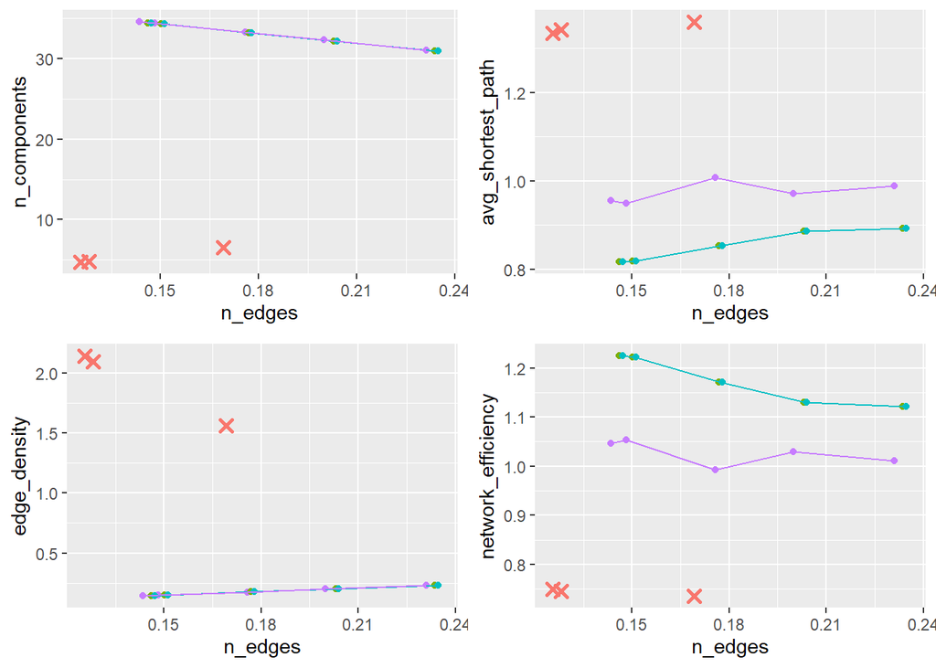

```r
p_n_components <- ggplot() +
  geom_point(data = subset(case_algo, type == "Case Study"),
             aes(x = n_edges, y = n_components, col = factor(type)),
             shape = 4, size = 2, stroke = 1.5) +
  geom_point(data = subset(case_algo, type %in% c("Random", "BFS", "DFS")),
            aes(x = n_edges, y = n_components, col = factor(type)),
            position = position_dodge(width = 0.002)) +
  geom_line(data = subset(case_algo, type %in% c("Random", "BFS", "DFS")),
            aes(x = n_edges, y = n_components, col = factor(type))) +
  # theme_minimal() +
  theme(legend.position = "none")

p_avg_shortest_path <- ggplot() +
  geom_point(data = subset(case_algo, type == "Case Study"),
             aes(x = n_edges, y = avg_shortest_path, col = factor(type)),
             shape = 4, size = 2, stroke = 1.5) +
  geom_point(data = subset(case_algo, type %in% c('Random', 'BFS', 'DFS')),
            aes(x = n_edges, y = avg_shortest_path, col = factor(type)),
            position = position_dodge(width = 0.002)) +
  geom_line(data = subset(case_algo, type %in% c('Random', 'BFS', 'DFS')),
            aes(x = n_edges, y = avg_shortest_path, col = factor(type))) +
  # theme_minimal() +
  theme(legend.position = "none")

p_edge_density <- ggplot() +
  geom_point(data = subset(case_algo, type == "Case Study"),
             aes(x = n_edges, y = edge_density, col = factor(type)),
             shape = 4, size = 2, stroke = 1.5) +
  geom_point(data = subset(case_algo, type %in% c('Random', 'BFS', 'DFS')),
            aes(x = n_edges, y = edge_density, col = factor(type)),
            position = position_dodge(width = 0.002)) +
  geom_line(data = subset(case_algo, type %in% c('Random', 'BFS', 'DFS')),
            aes(x = n_edges, y = edge_density, col = factor(type))) +
  # theme_minimal() +
  theme(legend.position = "none")

p_network_efficiency <- ggplot() +
  geom_point(data = subset(case_algo, type == "Case Study"),
             aes(x = n_edges, y = network_efficiency, col = factor(type)),
             shape = 4, size = 2, stroke = 1.5) +
  geom_point(data = subset(case_algo, type %in% c('Random', 'BFS', 'DFS')),
            aes(x = n_edges, y = network_efficiency, col = factor(type)),
            position = position_dodge(width = 0.002)) +
  geom_line(data = subset(case_algo, type %in% c('Random', 'BFS', 'DFS')),
            aes(x = n_edges, y = network_efficiency, col = factor(type))) +
  # theme_minimal() +
  guides(color = guide_legend(title = "Type of Method")) +
  theme(legend.position = "none")

p_avg_degree <- ggplot() +
  geom_point(data = subset(case_algo, type == "Case Study"),
             aes(x = n_edges, y = avg_degree, col = factor(type)),
             shape = 4, size = 2, stroke = 1.5) +
  geom_point(data = subset(case_algo, type %in% c('Random', 'BFS', 'DFS')),
            aes(x = n_edges, y = avg_degree, col = factor(type)),
            position = position_dodge(width = 0.002)) +
  geom_line(data = subset(case_algo, type %in% c('Random', 'BFS', 'DFS')),
            aes(x = n_edges, y = avg_degree, col = factor(type))) +
  # theme_minimal() +
  theme(legend.position = "none")

p_avg_betweenness <- ggplot() +
  geom_point(data = subset(case_algo, type == "Case Study"),
             aes(x = n_edges, y = avg_betweenness, col = factor(type)),
             shape = 4, size = 2, stroke = 1.5) +
  geom_point(data = subset(case_algo, type %in% c('Random', 'BFS', 'DFS')),
            aes(x = n_edges, y = avg_betweenness, col = factor(type)),
            position = position_dodge(width = 0.002)) +
  geom_line(data = subset(case_algo, type %in% c('Random', 'BFS', 'DFS')),
            aes(x = n_edges, y = avg_betweenness, col = factor(type))) +
  # theme_minimal() +
  theme(legend.position = "none")

p_avg_closeness <- ggplot() +
  geom_point(data = subset(case_algo, type == "Case Study"),
             aes(x = n_edges, y = avg_closeness, col = factor(type)),
             shape = 4, size = 2, stroke = 1.5) +
  geom_point(data = subset(case_algo, type %in% c('Random', 'BFS', 'DFS')),
            aes(x = n_edges, y = avg_closeness, col = factor(type)),
            position = position_dodge(width = 0.002)) +
  geom_line(data = subset(case_algo, type %in% c('Random', 'BFS', 'DFS')),
            aes(x = n_edges, y = avg_closeness, col = factor(type))) +
  # theme_minimal() +
  guides(color = guide_legend(title = "Type of Method")) +
  theme(legend.position = "none")

# get the legend ----
legend <- get_legend(
  ggplot() +
  geom_point(data = subset(case_algo, type == "Case Study"),
             aes(x = n_edges, y = avg_closeness, col = factor(type)),
             shape = 4, size = 2, stroke = 1.5) +
  geom_point(data = subset(case_algo, type %in% c('Random', 'BFS', 'DFS')),
            aes(x = n_edges, y = avg_closeness, col = factor(type)),
            position = position_dodge(width = 0.002)) +
  geom_line(data = subset(case_algo, type %in% c('Random', 'BFS', 'DFS')),
            aes(x = n_edges, y = avg_closeness, col = factor(type))) +
  guides(color = guide_legend(title = "Methods"))
)


plot_grid(p_n_components,p_avg_shortest_path,
          p_edge_density, p_network_efficiency,
          ncol = 2)
```

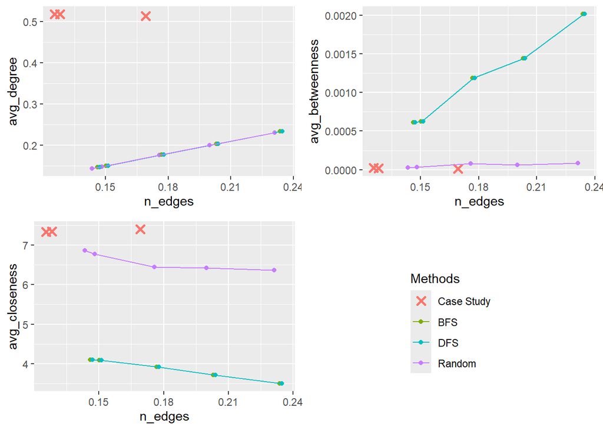

```r
plot_grid(p_avg_degree, p_avg_betweenness,
          p_avg_closeness, legend,
          ncol = 2)
```

To conclude, compared to other algorithms, the Random method is the best way to predict the vulnerability of the road against disasters. However, there are some trends of Random similar to BFS and DFS and it is difficult to assert that the Random method could adequately predict disrupted roads considering only three samples for the case study as well.

# 4 Conclusion

This study aimed to identify the critical nodes before and after the disasters in this region and evaluate the methods for the calculation of the vulnerability.

Centralities evaluated the important nodes in this region. The degree could detect the area where there is an active flow of traffic, and the road with the aligned nodes of high betweenness value would describe insufficient alternative paths during disasters. In this case, cities with high traffic flow were observed in northern inland and the essential road ran north-south in the middle of this peninsula. In contrast, the closeness centrality ignored the unreachable nodes, so coastal areas with comparatively short paths showed high closeness values, and the inland road with high betweenness illustrated lower closeness values, which meant the primary road basically was not efficient for accessing another node. Therefore, alternative paths or reinforcement of the main road could be the measures against natural disasters.

The random model predicted the road performance like the case study among all methods, so it could predict the vulnerability in the areas that are subject to natural disasters to a certain degree. The starting point in the BFS and DFS methods did not consider geographical features, and the algorithm focused only on the disruptions not recovery, and they can be potentially improved.

In addition to this, the road data in the original status was used as the total loss in the disasters to calculate the resilience. It is difficult to identify the status immediately after disasters, which could be one of the big issues in network resilience analysis.

(3040 words)

# 5 References

Anawat Suppasri, Miwako Kitamura, David Alexander, Shuji Seto, Fumihiko I.mamura, 2024, The 2024 Noto Peninsula earthquake: Preliminary observations and lessons to be learned, International Journal of Disaster Risk Reduction, Volume 110, 104611, ISSN 2212-4209, https://doi.org/10.1016/j.ijdrr.2024.104611.

Cutter, S.L., Mitchell, J.T. and Scott, M.S., 2000, Revealing the Vulnerability of People and Places: A Case Study of Georgetown County, South Carolina. Annals of the Association of American Geographers, 90: 713-737. https://doi.org/10.1111/0004-5608.00219.

Devanandham Henry, Jose Emmanuel Ramirez-Marquez, 2012, Generic metrics and quantitative approaches for system resilience as a function of time, Reliability Engineering & System Safety, Volume 99, Pages 114-122, ISSN 0951-8320, https://doi.org/10.1016/j.ress.2011.09.002.

Jiang, B., 1991. Traversing graphs in a paging environment, BFS or DFS? Inf. Process. Lett. 37 (3), 143–147.

Mehdi Taghizadeh, Mojtaba Mahsuli, Hossain Poorzahedy, 2023, Probabilistic framework for evaluating the seismic resilience of transportation systems during emergency medical response, Reliability Engineering & System Safety, Volume 236, 109255, ISSN 0951-8320, https://doi.org/10.1016/j.ress.2023.109255.

Nakajima, J., 2022, Crustal structure beneath earthquake swarm in the Noto peninsula, Japan.Earth Planets Space 74, 160. https://doi.org/10.1186/s40623-022-01719-x. Padgham, Mark. 2019. “Dodgr: An R Package for Network Flow Aggregation.” Findings, February. https://doi.org/10.32866/6945.

Zuofei Shen, Chengjun Ji, Shichang Lu, 2024, Transportation network resilience response to the spatial feature of hazards, Transportation Research Part D: Transport and Environment, Volume 128, 104121, ISSN 1361-9209, https://doi.org/10.1016/j.trd.2024.104121.